# Report of air monitoring research during Mar

### At location *ayxl*

date:2017-5-23

```
##       NO2             SO2          CO         Temp
##  Min.   :32.79   Min.   :0   Min.   :0   Min.   :26.20
##  1st Qu.:49.50   1st Qu.:0   1st Qu.:0   1st Qu.:26.30
##  Median :62.84   Median :0   Median :0   Median :26.70
##  Mean   :62.08   Mean   :0   Mean   :0   Mean   :26.61
##  3rd Qu.:69.33   3rd Qu.:0   3rd Qu.:0   3rd Qu.:26.80
##  Max.   :99.85   Max.   :0   Max.   :0   Max.   :27.10
```

date:2017-5-24

```
##       NO2              SO2                CO         Temp
##  Min.   : 42.40   Min.   :0.00000   Min.   :0   Min.   :29.60
##  1st Qu.: 69.86   1st Qu.:0.00000   1st Qu.:0   1st Qu.:29.70
##  Median : 77.46   Median :0.00000   Median :0   Median :29.80
##  Mean   : 76.37   Mean   :0.01379   Mean   :0   Mean   :29.93
##  3rd Qu.: 84.95   3rd Qu.:0.00000   3rd Qu.:0   3rd Qu.:30.20
##  Max.   :105.28   Max.   :0.10000   Max.   :0   Max.   :30.40
```

date:2017-5-25

```
##       NO2             SO2                 CO         Temp
##  Min.   :35.43   Min.   :0.000000   Min.   :0   Min.   :24.90
##  1st Qu.:50.35   1st Qu.:0.000000   1st Qu.:0   1st Qu.:25.10
##  Median :60.12   Median :0.000000   Median :0   Median :25.40
##  Mean   :59.34   Mean   :0.003333   Mean   :0   Mean   :25.31
##  3rd Qu.:69.48   3rd Qu.:0.000000   3rd Qu.:0   3rd Qu.:25.48
##  Max.   :77.56   Max.   :0.100000   Max.   :0   Max.   :25.60
```

date:2017-5-27

```
##       NO2              SO2                CO              Temp
##  Min.   : 59.29   Min.   :0.00000   Min.   :0.5000   Min.   :27.80
##  1st Qu.: 92.25   1st Qu.:0.00000   1st Qu.:0.5000   1st Qu.:28.30
##  Median :107.43   Median :0.00000   Median :0.6000   Median :28.80
##  Mean   :107.56   Mean   :0.01034   Mean   :0.6241   Mean   :28.87
##  3rd Qu.:124.51   3rd Qu.:0.00000   3rd Qu.:0.7000   3rd Qu.:29.50
##  Max.   :154.04   Max.   :0.10000   Max.   :0.8000   Max.   :29.80
```

date:2017-6-8

```
##       NO2              SO2                 CO               Temp
##  Min.   : 28.40   Min.   :0.000000   Min.   :0.00000   Min.   :26.80
##  1st Qu.: 48.44   1st Qu.:0.000000   1st Qu.:0.00000   1st Qu.:27.00
##  Median : 61.62   Median :0.000000   Median :0.00000   Median :27.20
##  Mean   : 59.61   Mean   :0.007692   Mean   :0.02308   Mean   :27.23
##  3rd Qu.: 68.61   3rd Qu.:0.000000   3rd Qu.:0.00000   3rd Qu.:27.40
##  Max.   :117.19   Max.   :0.100000   Max.   :0.20000   Max.   :27.80
```

### At location *nyxm*

date:2017-5-24

```
##        NO         Temp           NO2_C           NO2_C_S
##  Min.   :0   Min.   :32.70   Min.   : 80.65   Min.   : 76.19
##  1st Qu.:0   1st Qu.:32.80   1st Qu.:106.45   1st Qu.:109.17
##  Median :0   Median :32.90   Median :114.66   Median :119.65
##  Mean   :0   Mean   :32.97   Mean   :113.15   Mean   :117.74
##  3rd Qu.:0   3rd Qu.:33.17   3rd Qu.:118.92   3rd Qu.:125.10
##  Max.   :0   Max.   :33.40   Max.   :138.43   Max.   :150.04
```

date:2017-5-25

```
##        NO         Temp           NO2_C           NO2_C_S
##  Min.   :0   Min.   :27.50   Min.   : 74.07   Min.   : 67.79
##  1st Qu.:0   1st Qu.:27.85   1st Qu.: 88.85   1st Qu.: 86.67
##  Median :0   Median :28.10   Median : 94.61   Median : 94.04
##  Mean   :0   Mean   :28.04   Mean   : 94.66   Mean   : 94.09
##  3rd Qu.:0   3rd Qu.:28.25   3rd Qu.:100.54   3rd Qu.:101.61
##  Max.   :0   Max.   :28.50   Max.   :109.59   Max.   :113.18
```

date:2017-5-27

```
##        NO         Temp          NO2_C          NO2_C_S
##  Min.   :0   Min.   :31.6   Min.   :115.7   Min.   :121.0
##  1st Qu.:0   1st Qu.:31.9   1st Qu.:142.0   1st Qu.:154.6
##  Median :0   Median :32.2   Median :146.9   Median :160.9
##  Mean   :0   Mean   :32.2   Mean   :148.5   Mean   :162.9
##  3rd Qu.:0   3rd Qu.:32.5   3rd Qu.:155.9   3rd Qu.:172.4
##  Max.   :0   Max.   :33.0   Max.   :172.2   Max.   :193.2
```

date:2017-6-8

```
##       NO2              SO2                 CO              Temp
##  Min.   : 17.92   Min.   :0.000000   Min.   :0.4000   Min.   :29.10
##  1st Qu.: 54.77   1st Qu.:0.000000   1st Qu.:0.7000   1st Qu.:30.73
##  Median : 78.94   Median :0.000000   Median :0.9500   Median :32.30
##  Mean   : 73.50   Mean   :0.007692   Mean   :0.9077   Mean   :31.78
##  3rd Qu.: 93.95   3rd Qu.:0.000000   3rd Qu.:1.1000   3rd Qu.:32.75
##  Max.   :121.82   Max.   :0.100000   Max.   :1.3000   Max.   :33.60
```

## 2. Summary data by boxplot

Using boxplot to exhibit the difference between locations and date

### At location *assd*

First, summary all the data at location *assd*

```
##       Date                          NO2              SO2
##  Min.   :2017-05-22 17:10:50   Min.   :  3.71   Min.   :0.000000
##  1st Qu.:2017-05-23 17:35:36   1st Qu.: 35.31   1st Qu.:0.000000
##  Median :2017-05-25 17:31:02   Median : 61.23   Median :0.000000
##  Mean   :2017-05-27 15:19:16   Mean   : 68.45   Mean   :0.002013
##  3rd Qu.:2017-05-27 16:52:50   3rd Qu.: 90.86   3rd Qu.:0.000000
##  Max.   :2017-06-08 08:54:26   Max.   :173.81   Max.   :0.100000
##        CO              Temp       date.label
##  Min.   :0.0000   Min.   :20.20   5-22: 9
##  1st Qu.:0.0000   1st Qu.:27.40   5-23:29
##  Median :0.0000   Median :28.30   5-24:28
##  Mean   :0.4577   Mean   :28.75   5-25:29
##  3rd Qu.:0.9000   3rd Qu.:31.00   5-27:29
##  Max.   :1.6000   Max.   :32.60   6-8 :25
```

The boxplot show the NO2 concentration in diffrent days at location *assd*

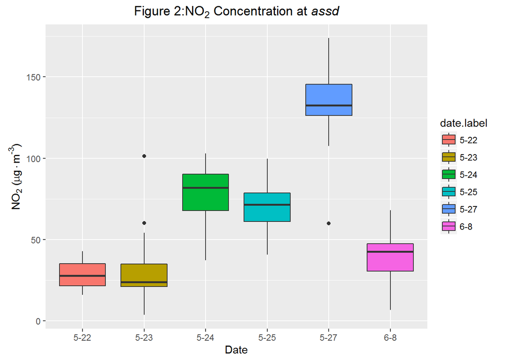

### At location *ayxl*

As usual, summary all the data at location *ayxl*

```
##       Date                          NO2              SO2
##  Min.   :2017-05-23 18:18:18   Min.   : 28.40   Min.   :0.000000
##  1st Qu.:2017-05-24 17:51:44   1st Qu.: 56.49   1st Qu.:0.000000
##  Median :2017-05-25 18:28:12   Median : 69.36   Median :0.000000
##  Mean   :2017-05-27 23:26:36   Mean   : 73.03   Mean   :0.006897
##  3rd Qu.:2017-05-27 17:52:19   3rd Qu.: 84.02   3rd Qu.:0.000000
##  Max.   :2017-06-08 09:40:15   Max.   :154.04   Max.   :0.100000
##        CO             Temp       date.label
##  Min.   :0.000   Min.   :24.90   5-23:31
##  1st Qu.:0.000   1st Qu.:26.30   5-24:29
##  Median :0.000   Median :27.20   5-25:30
##  Mean   :0.129   Mean   :27.57   5-27:29
##  3rd Qu.:0.000   3rd Qu.:29.50   6-8 :26
##  Max.   :0.800   Max.   :30.40
```

The boxplot show the NO2 concentration in diffrent days at location *ayxl*

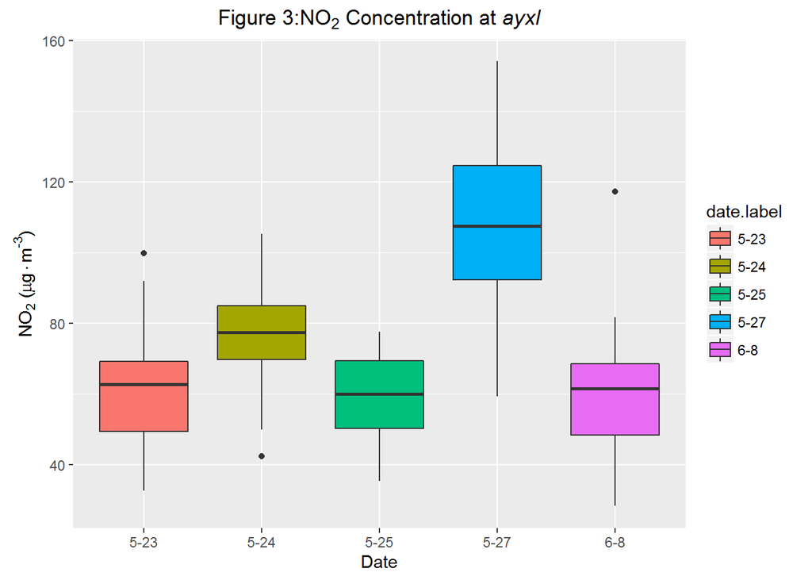

### At location *nyxm*

Here are some summary statistics of air data at location *nyxm*

```
##        NO         Temp           NO2_C           NO2_C_S       date.label
##  Min.   :0   Min.   :27.50   Min.   : 74.07   Min.   : 67.79   5-24:26
##  1st Qu.:0   1st Qu.:28.25   1st Qu.: 98.01   1st Qu.: 98.38   5-25:31
##  Median :0   Median :32.10   Median :115.37   Median :120.57   5-27:34
##  Mean   :0   Mean   :31.00   Mean   :120.07   Mean   :126.57
##  3rd Qu.:0   3rd Qu.:32.80   3rd Qu.:143.34   3rd Qu.:156.32
##  Max.   :0   Max.   :33.40   Max.   :172.19   Max.   :193.18
```

The boxplot show the NO2 concentration in diffrent days at location *nyxm*

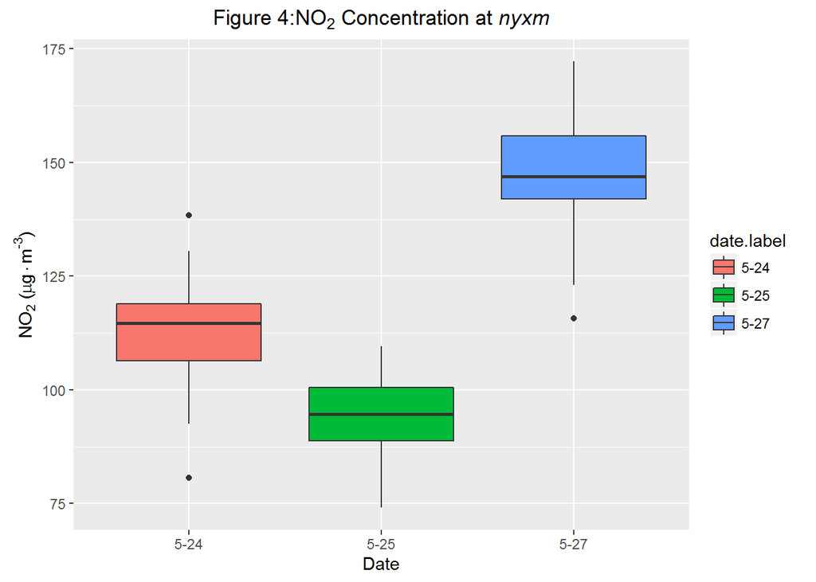

### Comparing between locations

We summary all the data in one table, that’s the result:

```
##       Date                          Temp            NO2         date.label
##  Min.   :2017-05-22 17:10:50   Min.   :20.20   Min.   :  3.71   5-22: 9
##  1st Qu.:2017-05-24 17:20:04   1st Qu.:27.10   1st Qu.: 54.16   5-23:60
##  Median :2017-05-25 18:23:12   Median :28.30   Median : 77.46   5-24:83
##  Mean   :2017-05-27 10:19:26   Mean   :28.84   Mean   : 82.37   5-25:90
##  3rd Qu.:2017-05-27 17:42:38   3rd Qu.:31.00   3rd Qu.:107.43   5-27:92
##  Max.   :2017-06-08 09:40:15   Max.   :33.40   Max.   :173.81   6-8 :51
##  Location
##  assd:149
##  ayxl:145
##  nyxm: 91
##
##
##
```

We also use boxplot to show the difference of Nirogen dioxide concentration between three locations

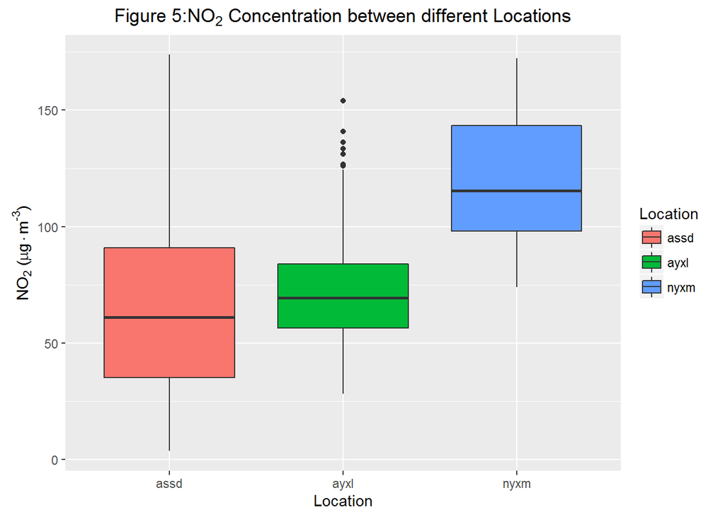

## 3. Multiple comparisons with air data

Multiple comparisons can test and caculate the true diffence of multiple data set. Here, we use this statistic method to reveal the relationship between locations and NO2 concentration.

### Using anova model to verify the difference effect of locations

First, We use anova model to verify the difference effect of locations. This table below is result

```
##              Df Sum Sq Mean Sq F value Pr(>F)
## Location      2 170850   85425   82.88 <2e-16 ***
## Residuals   382 393746    1031
## ---
## Signif. codes:  0 '***' 0.001 '**' 0.01 '*' 0.05 '.' 0.1 ' ' 1
```

The P value of *Location* is less than 0.01, It seems there were some diffence of NO2 concentration between 3 locations.

### Using multipe comparisons to estimate the difference value of NO2 concentration between 3 locations

We use Tukey HSD methd to estimate the difference value between 3 locations, here are results:

```
##
##   Simultaneous Tests for General Linear Hypotheses
##
## Multiple Comparisons of Means: Tukey Contrasts
##
##
## Fit: aov(formula = NO2 ~ Location, data = asno_mar_all)
##
## Linear Hypotheses:
##                  Estimate Std. Error t value Pr(>|t|)
## ayxl - assd == 0    4.574      3.745   1.221     0.44
## nyxm - assd == 0   51.617      4.271  12.084   <1e-04 ***
## nyxm - ayxl == 0   47.042      4.294  10.956   <1e-04 ***
## ---
## Signif. codes:  0 '***' 0.001 '**' 0.01 '*' 0.05 '.' 0.1 ' ' 1
## (Adjusted p values reported -- single-step method)
```

These figures below show the result of Tukey HSD test.

Here is the 95% confidence level of mean value with 3 pair-wise comparisons.

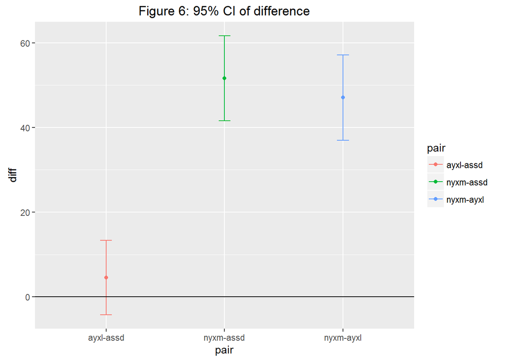

Here is result of Tukey HSD test.

all data

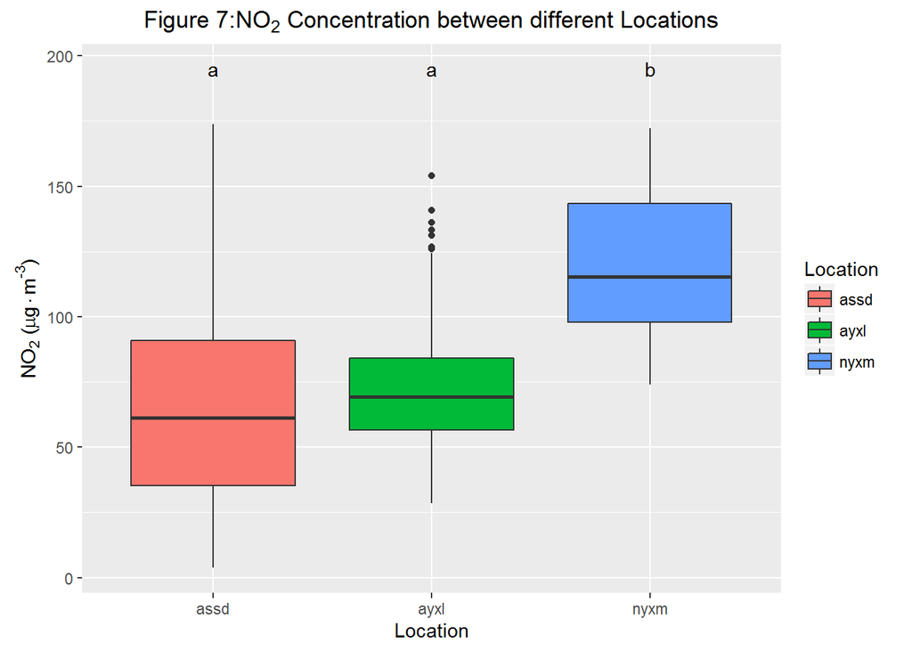

date:5-24, 5-25 and 5-27

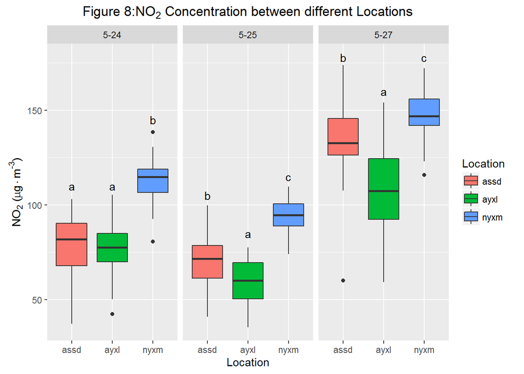

## 4. Compare the traffic flow between *nyxm* and *ayxl*

We also count the traffic flow during the 30min interval at traffic lane *nyxm* and *ayxl*, here is the result, displayed with boxplot and line plot

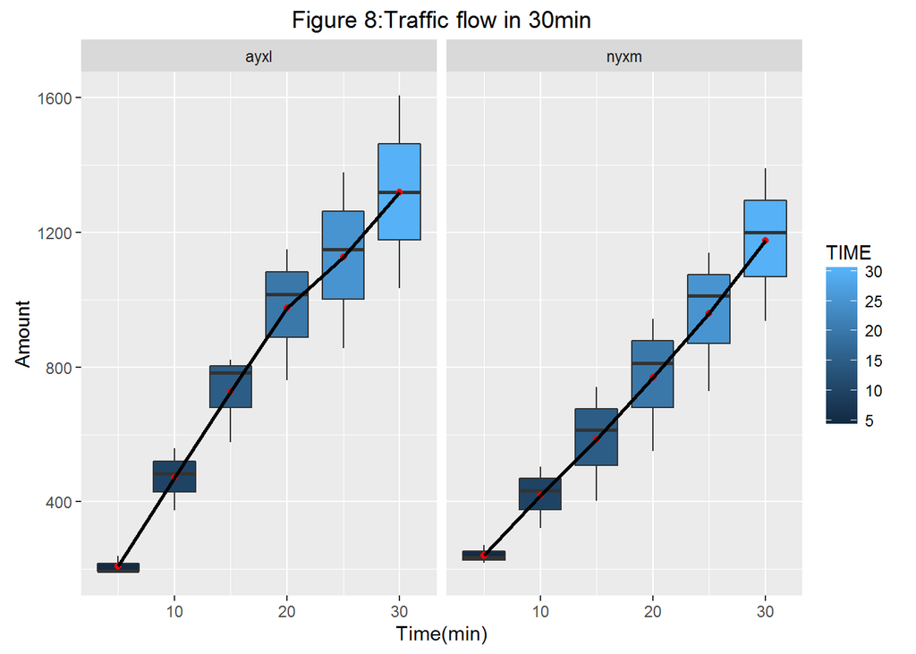

The plot shows the trend of traffic flow, we can find two locations exihibit similar rate of increase momentum in 30 min

We also tested the pair-wise comparison of traffic flow in 30 min, there is no significant difference between two location. The result has showed below

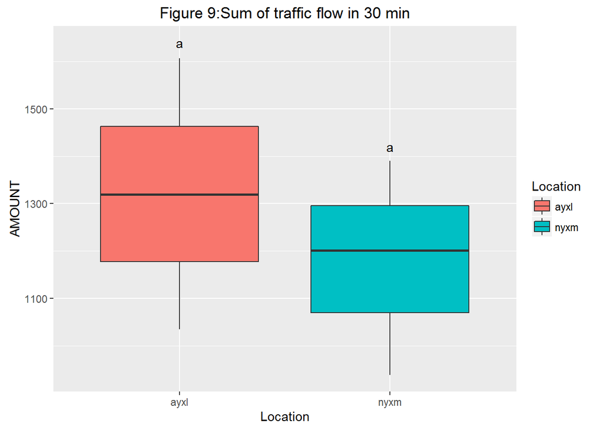